https://www.anaconda.com/download

https://htmlpreview.github.io/?https://github.com/IvanSibirevV2/AIS/blob/master/ЛабораторныеЗадания/001_Установка.html#/source

# Вебинар

Установка Windows Serwer 2012 R2 RU. VirtualBox

Скачать VirtualBox https://www.virtualbox.org/wiki/Downloads

[figure not shown]

[figure not shown]

[figure not shown]

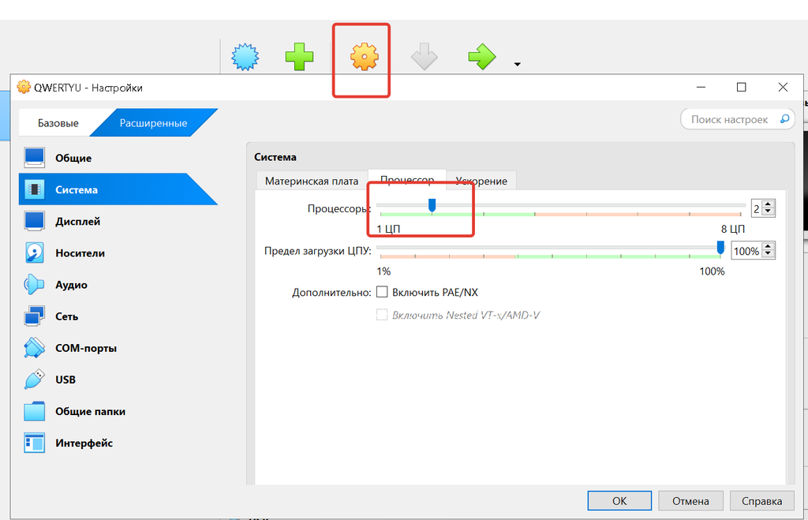

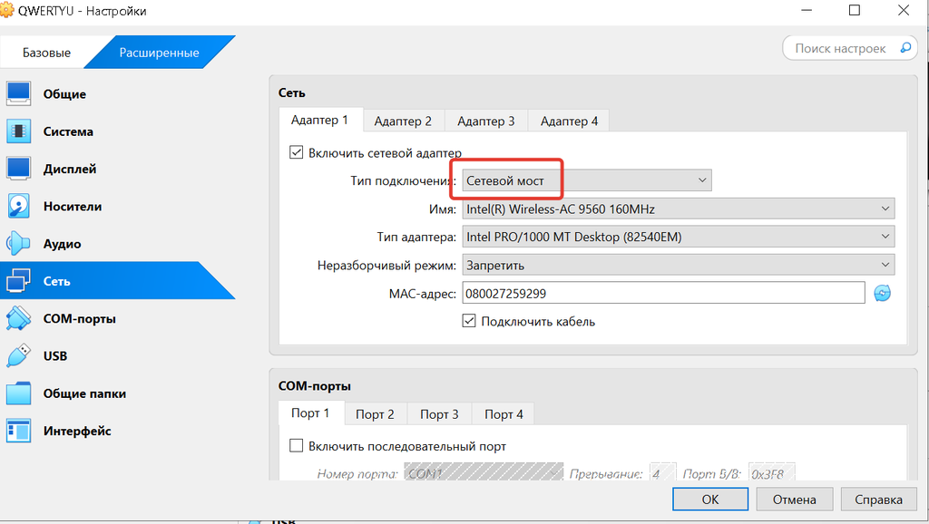

[figure not shown]

[figure not shown]

[figure not shown]

[figure not shown]

[figure not shown]

[figure not shown]

[figure not shown]

[2 more figures not shown]

После первого этапа установки, операционная система перезагружается и предлагает ввести/указать логин пароль.

Логин пароль, Например...

Admin123456789

[figure not shown]

[figure not shown]

[figure not shown]

В установленном виде виртуальный диск машины занимает 8 Гб

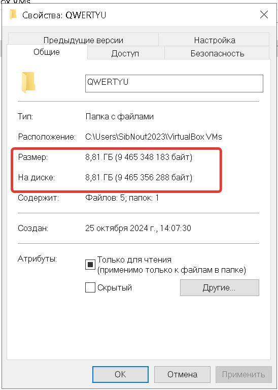

# Хотелось бы продемонстрировать еще один способ установки

[figure not shown]

[figure not shown]

Везде прожимаем далее. Дожидаемся окончания установки...

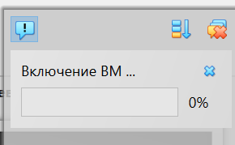

[figure not shown]

[figure not shown]

Так выглядит установленная версия Windows Server 2012 консольная без графического интерфейса

[figure not shown]

Занимает она установленная уже меньше места...

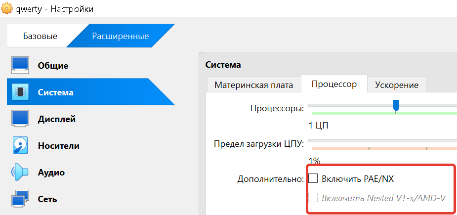

Виртуализация позволяет виртуальной машине обращаться не к програме процессора в оперативной памяти а к реальному процессору физического компьютера. Это значительно ускоряет работу виртуальной машины. Но для этого требуется включить VT-X, VT-D и возможно прочие виды виртуализации как на самой виртуальной машине в настройках, так и в настройках биоса. Последнее не всегда доступно. Некоторые более поздние операционные системы, такие как Windows 10 без настроенной и включенной виртуализации просто не работают. Убедительная просьба, постарайтесь работать на последней версии программного обеспечения VirtualBox...

# Есть еще и Hiper-v

[figure not shown]

[figure not shown]

# Еще есть VMware

Скачать лучше с официального сайта

https://support.broadcom.com/web/ecx/support-content-notification/-/external/content/SecurityAdvisories/0/24280

можно с торента https://gtorrent.cc/programmy/raznoe/201740-vmware-workstation-17-pro-1700-build-20800274-repack-by-kpojiuk-en.html

можно вот от сюда (Как оно сюда попало - правда не помню): https://github.com/IvanSibirevV2/Dist_VMware17.6.0ProKpoJIuK/tree/main

В 2024 году Broadcom сделала VMware Workstation Pro 17 бесплатным для личного использования. Как бесплатно использовать мощный инструмент для создания и управления виртуальными машинами на Windows и Linux https://www.comss.ru/page.php?id=13769

[figure not shown]

[figure not shown]

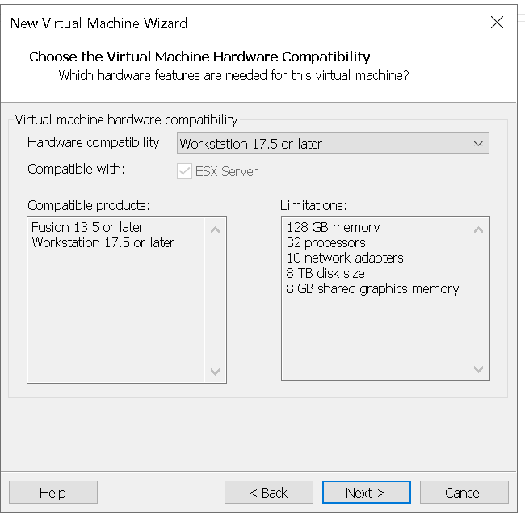

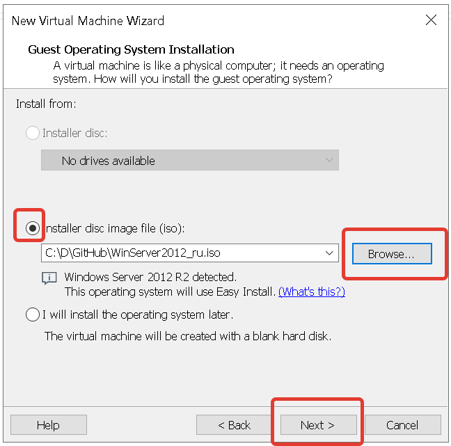

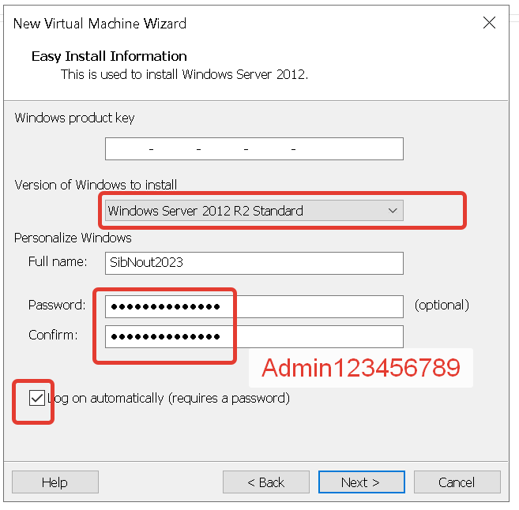

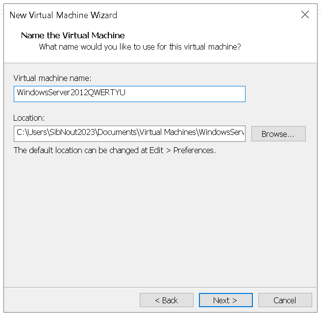